# Data Mining Project

### Cleaning and transforming the Data

##### Read in data and read convert values to 0/1/NA

```r
#linear regression
elementary <- read_csv("elementary.csv")

middle <- read_csv("middle.csv")

high <- read_csv("high.csv")
```

##### Create Transformation Functions

```r
#to transform and clean API
APITransform <- function(dataset){
  if(is.data.frame(dataset)){
  dataset <- transform(dataset,
                  API = mapvalues(API, c("Low","High","?"),
                                     c(0, 1, NA)))
   #Change ? to NA
   dataset[dataset == "?"] <- NA

  #This removes rows where API has null values
  dataset <- dataset[-which(is.na(dataset$API)), ]
  return(dataset)
  }
}

#Categorical Changes
 ChangeCategorical <-function(dataset){
     if(is.data.frame(dataset)){

       #Change to numeric
        dataset$ACS_CORE <- as.numeric(dataset$ACS_CORE)

       #Find the median(for ACS_CORE)
        median.ASC<- median(dataset$ACS_CORE, na.rm = TRUE)
        max.ASC <- max(dataset$ACS_CORE,na.rm = TRUE)
        dataset$ACS_CORE <- cut(dataset$ACS_CORE, c(1, median.ASC + 1, max.ASC),labels
                                     = FALSE)
        dataset$ACS_CORE[is.na(dataset$ACS_CORE)] <- 3

       #change ACS_CORE to categorical
        dataset$ACS_CORE <- factor(dataset$ACS_CORE)

       # Change Charter
        dataset$CHARTER[is.na(dataset$CHARTER)] <- 0
        dataset$CHARTER[dataset$CHARTER == "Y"] <- 1
        dataset$CHARTER[dataset$CHARTER == "D"] <- 2
        #change Year Round
        dataset$YR_RND[is.na(dataset$YR_RND)] <- 2
        dataset$YR_RND[dataset$YR_RND == "Yes"] <- 0
        dataset$YR_RND[dataset$YR_RND == "No"] <- 1

        #change to categorical
        dataset$CHARTER <- factor(dataset$CHARTER)
        dataset$YR_RND <- factor(dataset$YR_RND)

        #Change null values to 6
        dataset$AVG_ED[is.na(dataset$AVG_ED)] <- 6
        dataset$AVG_ED <- as.numeric(dataset$AVG_ED)
        dataset$AVG_ED <- round(dataset$AVG_ED, digits = 0)

        dataset$AVG_ED <- as.factor(dataset$AVG_ED)

        #Converting the Columns
        dataset$API <- factor(dataset$API)
        dataset$VALID <- as.numeric(dataset$VALID)
        dataset$NUMTEACH <- as.numeric(dataset$NUMTEACH)
        dataset$FULL_PCT <- as.numeric(dataset$FULL_PCT)
        dataset$EMER_PCT <- as.numeric(dataset$EMER_PCT)
        dataset$WVR_PCT <- as.numeric(dataset$WVR_PCT)
        dataset$YRS_TEACH <- as.numeric(dataset$YRS_TEACH)
        dataset$YRONE_TCH <- as.numeric(dataset$YRONE_TCH)
        dataset$YRTWO_TCH <- as.numeric(dataset$YRTWO_TCH)

       return(dataset)
     }
 }
```

##### Transform Data

```r
elementary.reg = APITransform(elementary)
elementary.reg = ChangeCategorical(elementary.reg)

high.reg = APITransform(high)
high.reg = ChangeCategorical(high.reg)

middle.reg = APITransform(middle)
middle.reg = ChangeCategorical(middle.reg)
```

##### Test and Training Data

```r
#Elementary
set.seed(1)
train1 <- sample(1:nrow(elementary.reg), nrow(elementary.reg)/2)
elementary.train <- as.data.frame(elementary.reg[train1,])

test1 <- (-train1)
elementary.test <- elementary.reg[test1,]

#Middle
set.seed(1)
train2 <- sample(1:nrow(middle.reg), nrow(middle.reg)/2)
middleschool.train <- as.data.frame(middle.reg[train2,])

test2 <- (-train2)
middleschool.test <- middle.reg[test2,]

#High School
set.seed(1)
train3 <- sample(1:nrow(high.reg), nrow(high.reg)/2)
highschool.train <- as.data.frame(high.reg[train3,])

test3 <- (-train3)
highschool.test <- high.reg[test3,]
```

##### Class Metrics Function

**Note: This metrics funtion is from homework 5**

```r
classMetrics <- function(score, y, cutoff,
                         type = c("all", "accuracy", "sensitivity",
                                  "specificity", "ppv", "npv", "precision",
                                  "recall")) {
  type <- match.arg(type, several.ok = TRUE)
  n <- length(y)

  # Form confusion matrix
  score.factor <- factor(as.numeric(score >= cutoff), levels = c("0", "1"))
  confusion.mat <- table(score.factor, as.factor(y), dnn = list("predicted", "observed"))

  # Calculate all metrics
  acc <- sum(diag(confusion.mat)) / n
  sens <- confusion.mat[2,2] / sum(confusion.mat[,2])
  spec <- confusion.mat[1,1] / sum(confusion.mat[,1])
  ppv <- confusion.mat[2,2] / sum(confusion.mat[2,])
  npv <- confusion.mat[1,1] / sum(confusion.mat[1,])
  prec <- ppv
  rec <- sens

  metric.names <- c("accuracy", "sensitivity", "specificity",
                    "ppv", "npv", "precision", "recall")
  metric.vals <- c(acc, sens, spec, ppv, npv, prec, rec)

  # Form into data frame
  full.df <- data.frame(value = metric.vals)
  rownames(full.df) <- metric.names

  # Return just the requested subset of metrics
  if(type[1] == "all") {
    list(conf.mat = confusion.mat, perf = full.df)
  } else {
    list(conf.mat = confusion.mat,
         perf = subset(full.df, subset = metric.names %in% type))
  }
}

plotClassMetrics <- function(score, y, xvar = NULL, yvar = c("accuracy", "sensitivity",
                                  "specificity", "ppv", "npv", "precision",
                                  "recall"),
                             flip.x = FALSE) {
  yvar <- match.arg(yvar)

  # If there are a lot of unique score values, just calculate the metrics
  # along an evenly spaced grid of 100 scores.
  unique.scores <- unique(score)
  if(length(unique.scores) > 100) {
    cutoff.seq <- sample(unique.scores, 100, replace = FALSE)
  } else {
    cutoff.seq <- unique.scores
  }

  n <- length(cutoff.seq)

  x.out <- numeric(n)
  y.out <- numeric(n)
  # Loop over all values of the score and calculate the performance metrics
  for(i in 1:n) {
    if(!is.null(xvar)) {
      metrics <- classMetrics(score, y, cutoff = cutoff.seq[i], type = c(xvar, yvar))
      x.out[i] <- metrics$perf[xvar, 1]
      y.out[i] <- metrics$perf[yvar, 1]
    } else {
      metrics <- classMetrics(score, y, cutoff = cutoff.seq[i], type = c(yvar))
      x.out[i] <- cutoff.seq[i]
      y.out[i] <- metrics$perf[yvar, 1]
    }
  }
  # Combine metrics into a data frame
  if(flip.x) {
    x.out <- 1 - x.out
  }
  df.out <- data.frame(score = cutoff.seq, x = x.out, y = y.out)
  # Reorder the data frame in increasing order of the x-axis variable
  df.out <- df.out[order(df.out$score), ]
  # De-duplicate x-axis
  df.out <- subset(df.out, subset = !duplicated(df.out$x))

  # Construct line plot
  if(!is.null(xvar)) {
    x.text <- ifelse(flip.x, paste0("1 - ", xvar), xvar)
  } else {
    x.text <- "score"
  }

  print(qplot(data = df.out, x = x, y = y, geom = "line",
              xlab = ifelse(is.null(xvar), "score", x.text),
              ylab = yvar, ylim = c(0, 1)))
}
```

### Models

#### Logistic regressions

**In the following, we fit logistic regressions on all the grade level data separately (elementary school, middle school, and high school) and plotted API probability histograms** ##### Elementary School

```r
#Logistic regression
elementary.log <- glm(API ~., family = binomial, data = elementary.reg)

#ggplot(elementary.train, aes(elementary.log$fitted.values, fill = as.factor(elementary.log$y))) + geom_histogram() + labs(fill = "API", title = "Estimated API Probabilities Histogram", x = "Estimated API Probabilities") + theme_classic()

data.frame(summary(elementary.log)$coef[summary(elementary.log)$coef[,4] <= .05, 1])
```

```
##             summary.elementary.log..coef.summary.elementary.log..coef...4.....
## (Intercept)                                                        -2.37842297
## CHARTER2                                                           -0.55246627
## VALID                                                               0.00250947
## AA_SIGYes                                                          -0.67641786
## AS_SIGYes                                                           1.24232044
## WH_SIGYes                                                           1.06720097
## SD_SIGYes                                                          -0.63111772
## YR_RND2                                                            -1.26079128
## ACS_CORE3                                                           0.71806010
## AVG_ED3                                                             2.67447721
## AVG_ED4                                                             4.46101915
## AVG_ED5                                                             3.98471867
## AVG_ED6                                                             1.75157979
## NUMTEACH                                                           -0.02967013
## YRTWO_TCH                                                          -0.08933608
```

**For elementary school data, the variables that are statistically significant (p < 0.05) are Charter 2(negative), Valid(positive), AA_SIGYes(negative), AS_SIGYes(positive), WH_SIGYes(positive), SD_SIGYes(negative), YR_RND2(negative),ACS_CORE3(positive),AVG_ED3(positive),AVG_ED4(positive),AVG_ED5(positive), AVG_ED6(positive), NUMTEACH(negative), and YRTWO_TCH(negative).**

###### Confusion Matrix

```r
cat("Training Data Confusion Matrix \n")
```

```
## Training Data Confusion Matrix
```

```r
elementary.logit <- glm(API ~., family = binomial, data = elementary.train)
# Training data confusion matrix
confusion.logit.train <- table(round(elementary.logit$fitted), elementary.logit$y)
confusion.logit.train
```

```
##
##        0    1
##   0 1063  245
##   1  258 1039
```

```r
#Training data misclassification rate
1 - sum(diag(confusion.logit.train)) / sum(confusion.logit.train)
```

```
## [1] 0.1930902
```

```r
cat(" \n Test Data Confusion Matrix")
```

```
##
##  Test Data Confusion Matrix
```

```r
# Test data confusion matrix
test.probs <- predict(elementary.logit, elementary.test, type = "response")
confusion.logit.test <- table(round(test.probs), elementary.test$API)
confusion.logit.test
```

```
##
##        0    1
##   0 1073  208
##   1  244 1081
```

```r
# Test data misclassification rate
1 - sum(diag(confusion.logit.test)) / sum(confusion.logit.test)
```

```
## [1] 0.1734459
```

##### Middle School

```r
middle.log <- glm(API ~., family = binomial, data = middle.reg)
#ggplot(middle.reg, aes(middle.log$fitted.values, fill = as.factor(middle.log$y))) + geom_histogram() + labs(fill = "API", title = "Estimated API Probabilities Histogram", x = "Estimated API Probabilities") + theme_classic()

data.frame(summary(middle.log)$coef[summary(middle.log)$coef[,4] <= .05, 1])
```

```
##           summary.middle.log..coef.summary.middle.log..coef...4.....0.05..
## CHARTER2                                                       2.403567609
## VALID                                                          0.007605156
## AA_SIGYes                                                     -1.068432650
## AS_SIGYes                                                      1.634004051
## WH_SIGYes                                                      1.269098954
## NUMTEACH                                                      -0.170796127
## FULL_PCT                                                       3.683213585
## YRONE_TCH                                                     -0.121115198
```

###### Confusion Matrix

```r
cat("Training Data Confusion Matrix \n")
```

```
## Training Data Confusion Matrix
```

```r
middle.logit <- glm(API ~., family = binomial, data = middleschool.train)
# Training data confusion matrix
confusion.logit.train <- table(round(middle.logit$fitted), middle.logit$y)
confusion.logit.train
```

```
##
##       0   1
##   0 245  38
##   1  43 265
```

```r
#Training data misclassification rate
1 - sum(diag(confusion.logit.train)) / sum(confusion.logit.train)
```

```
## [1] 0.1370558
```

```r
cat(" \n Test Data Confusion Matrix")
```

```
##
##  Test Data Confusion Matrix
```

```r
# Test data confusion matrix
test.probs <- predict(middle.logit, middleschool.test, type = "response")
confusion.logit.test <- table(round(test.probs), middleschool.test$API)
confusion.logit.test
```

```
##
##       0   1
##   0 259  46
##   1  49 238
```

```r
# Test data misclassification rate
1 - sum(diag(confusion.logit.test)) / sum(confusion.logit.test)
```

```
## [1] 0.160473
```

##### High School

```r
high.log <- glm(API ~., family = binomial, data = high.reg)
#ggplot(high.reg, aes(high.log$fitted.values, fill = as.factor(high.log$y))) + geom_histogram() + labs(fill = "API", title = "Estimated API Probabilities Histogram", x = "Estimated API Probabilities") + theme_classic()

data.frame(summary(high.log)$coef[summary(high.log)$coef[,4] <= .05, 1])
```

```
##             summary.high.log..coef.summary.high.log..coef...4.....0.05..1.
## (Intercept)                                                   -5.006398568
## VALID                                                          0.003735276
## AA_SIGYes                                                     -1.246162695
## AS_SIGYes                                                      1.597462751
## WH_SIGYes                                                      0.801124912
## SD_SIGYes                                                      1.115595188
## AVG_ED3                                                        1.735781613
## AVG_ED4                                                        4.593965182
## AVG_ED6                                                        2.789035165
## NUMTEACH                                                      -0.063376622
```

```r
cat("Training Data Confusion Matrix \n")
```

```
## Training Data Confusion Matrix
```

```r
high.logit <- glm(API ~., family = binomial, data = highschool.train)
# Training data confusion matrix
confusion.logit.train <- table(round(high.logit$fitted), high.logit$y)
confusion.logit.train
```

```
##
##       0   1
##   0 285  55
##   1  53 229
```

```r
#Training data misclassification rate
1 - sum(diag(confusion.logit.train)) / sum(confusion.logit.train)
```

```
## [1] 0.1736334
```

```r
cat(" \n Test Data Confusion Matrix")
```

```
##
##  Test Data Confusion Matrix
```

```r
# Test data confusion matrix
test.probs <- predict(high.logit, highschool.test, type = "response")
confusion.logit.test <- table(round(test.probs), highschool.test$API)
confusion.logit.test
```

```
##
##       0   1
##   0 280  55
##   1  60 228
```

```r
# Test data misclassification rate
1 - sum(diag(confusion.logit.test)) / sum(confusion.logit.test)
```

```
## [1] 0.1845907
```

#### Forward Stepwise

##### Function

```r
forwardStepwise <- function(dataset,title){
  if(is.data.frame(dataset)){
    forward <- regsubsets(API~.,
                                    data=dataset,
                                    nbest = 1,
                                    nvmax = NULL,
                                    method="forward", really.big=TRUE)
    # display variables in each model for the fist 12 models
    for(i in 1:12){
      co = coef(forward, id=i)
      print(i)
      print(co)
    }

    summary = summary(forward)

    # plot rsq on the y-axis
    plot(summary$rsq, xlab="model size", ylab="R-squared", type = "l",main = paste(title,"R-Squared", sep="\n"))
    # plot showing BIC on the y-axis and
    plot(summary$bic, xlab="Model Size", ylab="BIC",type = "l", main = paste(title,"BIC",sep="\n"))
    return(forward)
  }
}
```

##### Elementary School

```r
elem.stepWise <- forwardStepwise(elementary.reg, "Elementary School")
```

```
## [1] 1
## (Intercept)     AVG_ED2
##   1.7305466  -0.5872815
## [1] 2
## (Intercept)     AVG_ED2     AVG_ED4
##   1.6390773  -0.4958122   0.3164288
## [1] 3
## (Intercept)   WH_SIGYes     AVG_ED2     AVG_ED4
##   1.5014808   0.2114148  -0.3953466   0.2614238
## [1] 4
## (Intercept)   AS_SIGYes   WH_SIGYes     AVG_ED2     AVG_ED4
##   1.4669474   0.1814159   0.2284186  -0.3759746   0.2340532
## [1] 5
## (Intercept)   AS_SIGYes   WH_SIGYes     AVG_ED2     AVG_ED3     AVG_ED4
##   1.3188181   0.1923619   0.2179874  -0.2267478   0.1721064   0.3888850
## [1] 6
## (Intercept)   AS_SIGYes   WH_SIGYes     AVG_ED2     AVG_ED3     AVG_ED4
##  1.18988222  0.16940055  0.19942019 -0.09301003  0.31618116  0.54061026
##     AVG_ED5
##  0.49633264
## [1] 7
## (Intercept)   AA_SIGYes   AS_SIGYes   WH_SIGYes     AVG_ED2     AVG_ED3
##  1.19516370 -0.11581460  0.16766013  0.18977364 -0.08374694  0.33016356
##     AVG_ED4     AVG_ED5
##  0.54636574  0.50010466
## [1] 8
## (Intercept)   AA_SIGYes   AS_SIGYes   WH_SIGYes     AVG_ED2     AVG_ED3
##  1.05464571 -0.11759019  0.15656217  0.18083454  0.05928105  0.47816660
##     AVG_ED4     AVG_ED5     AVG_ED6
##  0.69789430  0.65492324  0.34115926
## [1] 9
## (Intercept)   AA_SIGYes   AS_SIGYes   WH_SIGYes     AVG_ED2     AVG_ED3
##  1.08562915 -0.11123758  0.15920449  0.18120335  0.05274036  0.46429906
##     AVG_ED4     AVG_ED5     AVG_ED6   YRTWO_TCH
##  0.68287433  0.64192496  0.32420193 -0.01677582
## [1] 10
## (Intercept)    CHARTER2   AA_SIGYes   AS_SIGYes   WH_SIGYes     AVG_ED2
##  1.08577946 -0.10158786 -0.11010782  0.15335207  0.17736080  0.05362394
##     AVG_ED3     AVG_ED4     AVG_ED5     AVG_ED6   YRTWO_TCH
##  0.46923567  0.69264337  0.64952301  0.33222364 -0.01507804
## [1] 11
## (Intercept)    CHARTER2   AA_SIGYes   AS_SIGYes   WH_SIGYes   SD_SIGYes
##  1.13243868 -0.10975534 -0.10571099  0.15434268  0.17990143 -0.04985030
##     AVG_ED2     AVG_ED3     AVG_ED4     AVG_ED5     AVG_ED6   YRTWO_TCH
##  0.05333328  0.46359958  0.65958097  0.60073412  0.31179642 -0.01415644
## [1] 12
## (Intercept)    CHARTER2   AA_SIGYes   AS_SIGYes   WH_SIGYes   SD_SIGYes
##  1.14100791 -0.10996184 -0.10644755  0.15277363  0.17861721 -0.05807673
##     YR_RND2     AVG_ED2     AVG_ED3     AVG_ED4     AVG_ED5     AVG_ED6
## -0.22713364  0.05414422  0.46556971  0.65714591  0.59477107  0.30942331
##   YRTWO_TCH
## -0.01442828
```

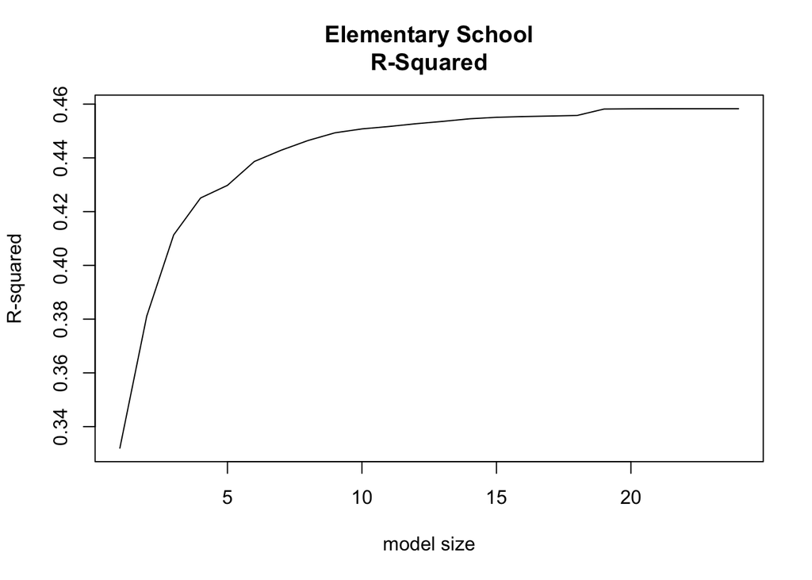

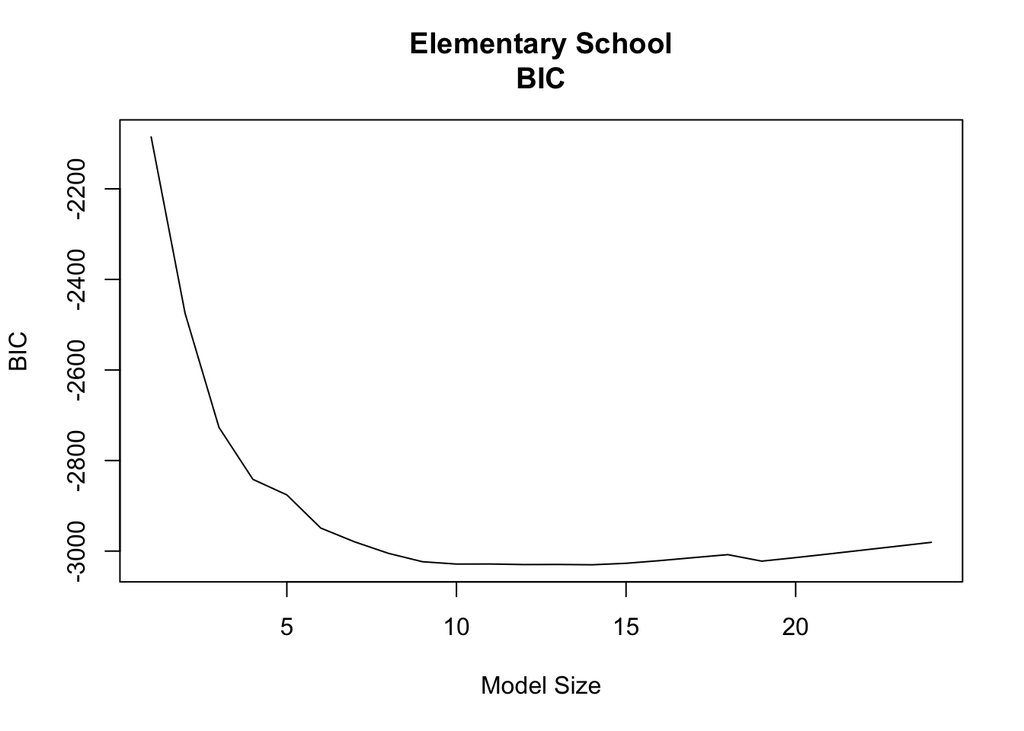

###### Model with Min BIC

```r
min.bic <- which.min(summary(elem.stepWise)$bic)
coef(elem.stepWise, min.bic)
```

```
## (Intercept)    CHARTER2   AA_SIGYes   AS_SIGYes   WH_SIGYes   SD_SIGYes
##  1.03603330 -0.08725320 -0.10589582  0.15235390  0.18133417 -0.05875146
##     YR_RND2   ACS_CORE2   ACS_CORE3     AVG_ED2     AVG_ED3     AVG_ED4
## -0.23205492  0.11471077  0.10692790  0.05457458  0.46622413  0.65514952
##     AVG_ED5     AVG_ED6   YRTWO_TCH
##  0.59260345  0.31205171 -0.01384587
```

##### Middle School

```r
middle.stepWise <- forwardStepwise(middle.reg,"Middle School")
```

```
## [1] 1
## (Intercept)     AVG_ED2
##   1.7677225  -0.6177225
## [1] 2
## (Intercept)   WH_SIGYes     AVG_ED2
##   1.5543547   0.2451696  -0.4769626
## [1] 3
## (Intercept)   AS_SIGYes   WH_SIGYes     AVG_ED2
##   1.4881830   0.2153959   0.2558759  -0.4346728
## [1] 4
## (Intercept)   AS_SIGYes   WH_SIGYes     AVG_ED2     AVG_ED4
##   1.4628761   0.1829999   0.2363278  -0.4004616   0.2175938
## [1] 5
## (Intercept)   AA_SIGYes   AS_SIGYes   WH_SIGYes     AVG_ED2     AVG_ED4
##   1.4997072  -0.1454171   0.1912707   0.2247948  -0.4041908   0.1912165
## [1] 6
## (Intercept)   AA_SIGYes   AS_SIGYes   WH_SIGYes     AVG_ED2     AVG_ED4
##   1.5317764  -0.1374291   0.1944956   0.2113692  -0.3935802   0.1923733
##   YRONE_TCH
##  -0.0161387
## [1] 7
## (Intercept)    CHARTER2   AA_SIGYes   AS_SIGYes   WH_SIGYes     AVG_ED2
##  1.50662780  0.14994504 -0.14293197  0.20406772  0.23030843 -0.38188970
##     AVG_ED4   YRONE_TCH
##  0.19038282 -0.01613545
## [1] 8
## (Intercept)    CHARTER2   AA_SIGYes   AS_SIGYes   WH_SIGYes     AVG_ED2
##  0.91806228  0.31415141 -0.13613082  0.19652791  0.21281685 -0.38447553
##     AVG_ED4    FULL_PCT   YRONE_TCH
##  0.18566055  0.62047025 -0.01252759
## [1] 9
## (Intercept)    CHARTER2   AA_SIGYes   AS_SIGYes   WH_SIGYes   ACS_CORE2
##  0.90201708  0.32854950 -0.14184592  0.18974786  0.21028143  0.06428907
##     AVG_ED2     AVG_ED4    FULL_PCT   YRONE_TCH
## -0.37848765  0.17888487  0.61294874 -0.01170586
## [1] 10
## (Intercept)    CHARTER2   AA_SIGYes   AS_SIGYes   HI_SIGYes   WH_SIGYes
##  0.97507757  0.31752064 -0.13780278  0.18832622 -0.09161254  0.21250124
##   ACS_CORE2     AVG_ED2     AVG_ED4    FULL_PCT   YRONE_TCH
##  0.07376185 -0.36928618  0.15533071  0.61226223 -0.01050079
## [1] 11
## (Intercept)    CHARTER2   AA_SIGYes   AS_SIGYes   HI_SIGYes   WH_SIGYes
##  0.84869907  0.30647372 -0.14587459  0.19755354 -0.11172826  0.20258243
##   ACS_CORE2     AVG_ED2     AVG_ED3     AVG_ED4    FULL_PCT   YRONE_TCH
##  0.07505108 -0.18380706  0.20219380  0.33727938  0.57331357 -0.01031594
## [1] 12
## (Intercept)    CHARTER2   AA_SIGYes   AS_SIGYes   HI_SIGYes   WH_SIGYes
##  0.72895987  0.30521307 -0.14696968  0.18547453 -0.08879202  0.18991454
##   ACS_CORE2     AVG_ED2     AVG_ED3     AVG_ED4     AVG_ED5    FULL_PCT
##  0.07786778 -0.06167962  0.33399211  0.47925547  0.39051459  0.55261724
##   YRONE_TCH
## -0.01057570
```

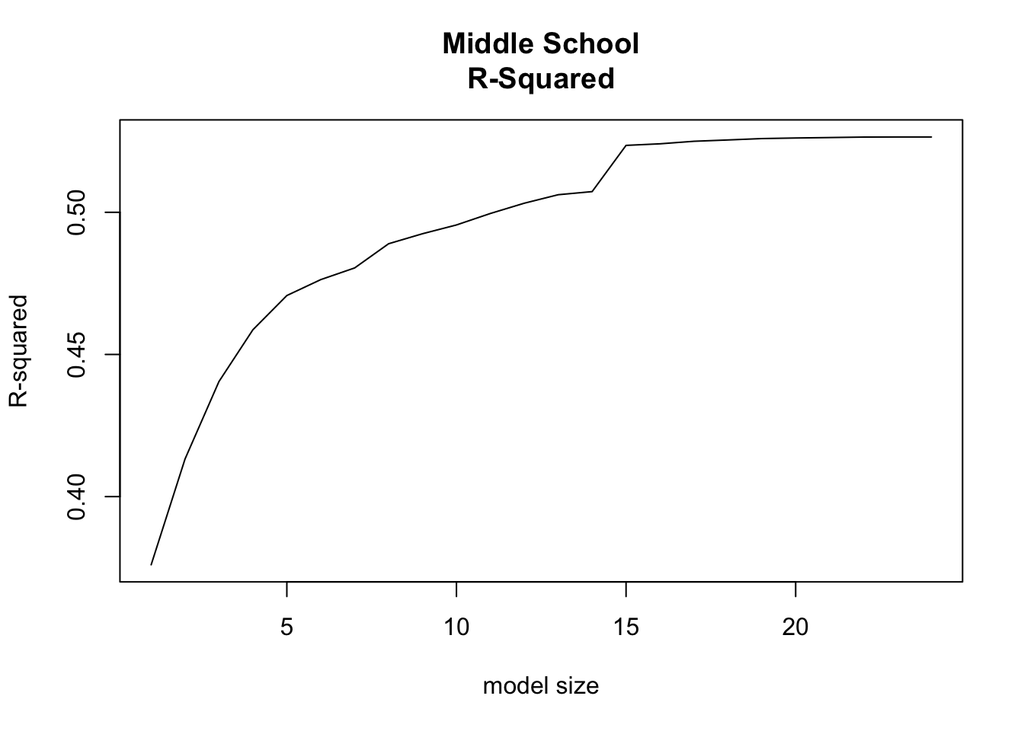

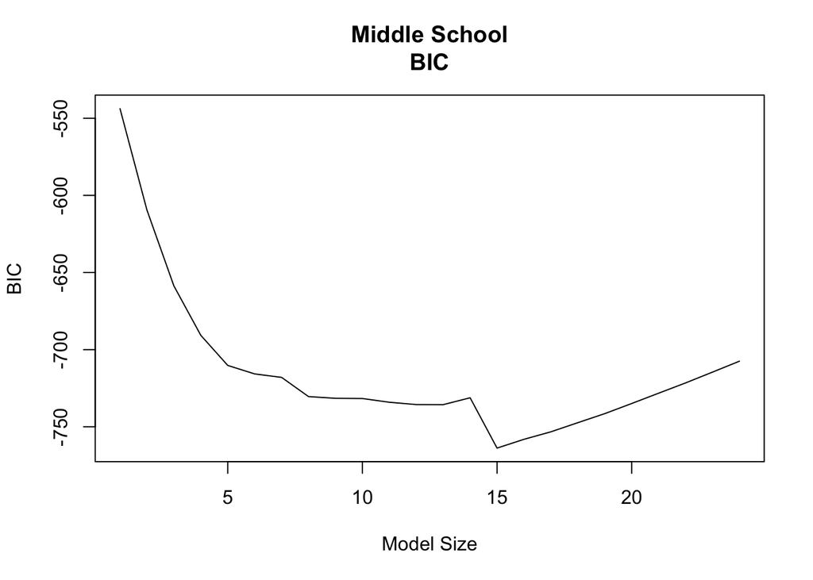

###### Model with Min BIC

```r
min.bic <- which.min(summary(middle.stepWise)$bic)
coef(middle.stepWise, min.bic)
```

```
##   (Intercept)      CHARTER2         VALID     AA_SIGYes     AS_SIGYes
##  0.6194111693  0.2770311948  0.0006624952 -0.1275451546  0.1488721492
##     HI_SIGYes     WH_SIGYes     ACS_CORE2       AVG_ED2       AVG_ED3
## -0.0930322958  0.1643415411  0.0044872027  0.0796711640  0.4562414705
##       AVG_ED4       AVG_ED5       AVG_ED6      NUMTEACH      FULL_PCT
##  0.6011251803  0.6061554028  0.4186962717 -0.0139267174  0.5810212973
##     YRONE_TCH
## -0.0062665123
```

##### High School

```r
high.stepWise <- forwardStepwise(high.reg, "High School")
```

```
## [1] 1
## (Intercept)     AVG_ED2
##   1.6720214  -0.5414993
## [1] 2
## (Intercept)   AS_SIGYes     AVG_ED2
##    1.589988    0.298920   -0.500883
## [1] 3
## (Intercept)   AS_SIGYes   WH_SIGYes     AVG_ED2
##   1.4398209   0.2603658   0.2052630  -0.4208015
## [1] 4
## (Intercept)   AS_SIGYes   WH_SIGYes     AVG_ED2     AVG_ED4
##   1.4043164   0.2190993   0.1962480  -0.3762666   0.2738453
## [1] 5
## (Intercept)   AA_SIGYes   AS_SIGYes   WH_SIGYes     AVG_ED2     AVG_ED4
##   1.4171745  -0.1450764   0.2451640   0.2070990  -0.3626393   0.2523379
## [1] 6
## (Intercept)   AA_SIGYes   AS_SIGYes   WH_SIGYes   SD_SIGYes     AVG_ED2
##   1.3548846  -0.1680666   0.2254970   0.1669087   0.1328574  -0.3924374
##     AVG_ED4
##   0.2895497
## [1] 7
## (Intercept)   AA_SIGYes   AS_SIGYes   WH_SIGYes   SD_SIGYes     YR_RND1
##   1.2308859  -0.1689099   0.2236156   0.1609268   0.1151143   0.1499041
##     AVG_ED2     AVG_ED4
##  -0.3909985   0.2836435
## [1] 8
## (Intercept)   AA_SIGYes   AS_SIGYes   WH_SIGYes   SD_SIGYes     YR_RND1
##   1.2468954  -0.1660670   0.2196948   0.1535430   0.1218748   0.1467640
##     AVG_ED2     AVG_ED4    EMER_PCT
##  -0.3942080   0.2808889  -0.5024671
## [1] 9
##  (Intercept)    AA_SIGYes    AS_SIGYes    WH_SIGYes    SD_SIGYes
##  1.254455127 -0.161609684  0.227208088  0.151732373  0.135809991
##      YR_RND1      AVG_ED2      AVG_ED4     EMER_PCT    YRONE_TCH
##  0.140199248 -0.388711026  0.281902135 -0.485767718 -0.005448368
## [1] 10
##  (Intercept)    AA_SIGYes    AS_SIGYes    WH_SIGYes    SD_SIGYes
##  1.253153923 -0.160535787  0.222132659  0.149330358  0.142376486
##      YR_RND1      AVG_ED2      AVG_ED4      AVG_ED5     EMER_PCT
##  0.137774781 -0.388895289  0.286854383  0.262120061 -0.489286852
##    YRONE_TCH
## -0.005578841
## [1] 11
##  (Intercept)    AA_SIGYes    AS_SIGYes    WH_SIGYes    SD_SIGYes
##  1.133486412 -0.164354384  0.226507131  0.143998061  0.142600447
##      YR_RND1      AVG_ED2      AVG_ED3      AVG_ED4      AVG_ED5
##  0.137781296 -0.268274926  0.128014893  0.408698750  0.381978302
##     EMER_PCT    YRONE_TCH
## -0.467308651 -0.005441733
## [1] 12
##  (Intercept)    AA_SIGYes    AS_SIGYes    WH_SIGYes    SD_SIGYes
##  0.969367809 -0.164533848  0.218939132  0.136125562  0.153978041
##      YR_RND1      AVG_ED2      AVG_ED3      AVG_ED4      AVG_ED5
##  0.138056513 -0.110681976  0.290293895  0.576957123  0.561114109
##      AVG_ED6     EMER_PCT    YRONE_TCH
##  0.417455226 -0.430528577 -0.005587198
```

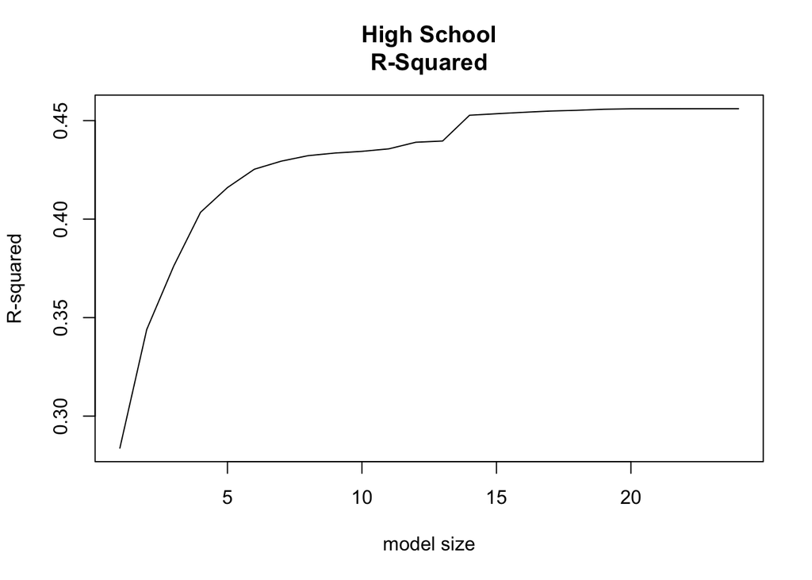

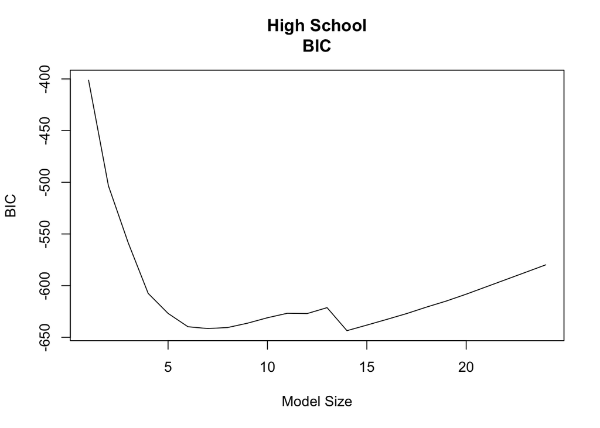

######Model with Min BIC

```r
min.bic <- which.min(summary(high.stepWise)$bic)
coef(high.stepWise, min.bic)
```

```
##   (Intercept)         VALID     AA_SIGYes     AS_SIGYes     WH_SIGYes
##  1.0082327640  0.0003577157 -0.1558540804  0.2053502239  0.1416538473
##     SD_SIGYes       YR_RND1       AVG_ED2       AVG_ED3       AVG_ED4
##  0.1537500058  0.1123823866 -0.0895525870  0.2986116249  0.5741430032
##       AVG_ED5       AVG_ED6      NUMTEACH      EMER_PCT     YRONE_TCH
##  0.6820417827  0.3820122209 -0.0062631166 -0.4624407349 -0.0019191645
```

#### Lasso

##### Elementary

```r
#removing all rows where API is null
elementary.reg2 = elementary.reg

elem.x <- model.matrix(API~.,elementary.reg2)[,-1]
elem.y <- as.matrix(data.frame(elementary.reg$API))
#Need to change y to numeric to run cross validation
elem.y <- as.numeric(elem.y)

full <- data.frame(elem.x,elem.y)
# Split data into test and train
set.seed(1)
elem.train <- sample(1:nrow(elem.x), nrow(elem.x)/2)
e<-as.data.frame(elem.train)
elem.test <- (-elem.train)
elem.y.test <- elem.y[elem.test]

# If we want to specify the number of lambda values - not sure we actually need this
# Predefined grid of lambda values:
# grid=10^seq(10,-2, length =100)

#lasso
elem.glm <- glmnet(elem.x[elem.train,],elem.y[elem.train],family = "binomial",alpha=1)
elem.glm
```

```
##
## Call:  glmnet(x = elem.x[elem.train, ], y = elem.y[elem.train], family = "binomial",      alpha = 1)
##
##       Df       %Dev    Lambda
##  [1,]  0 -3.476e-14 0.2773000
##  [2,]  1  3.773e-02 0.2527000
##  [3,]  1  6.923e-02 0.2302000
##  [4,]  1  9.563e-02 0.2098000
##  [5,]  1  1.178e-01 0.1911000
##  [6,]  2  1.408e-01 0.1742000
##  [7,]  3  1.628e-01 0.1587000
##  [8,]  3  1.845e-01 0.1446000
##  [9,]  3  2.031e-01 0.1317000
## [10,]  3  2.191e-01 0.1200000
## [11,]  3  2.328e-01 0.1094000
```

[output cut: 71 more lines]

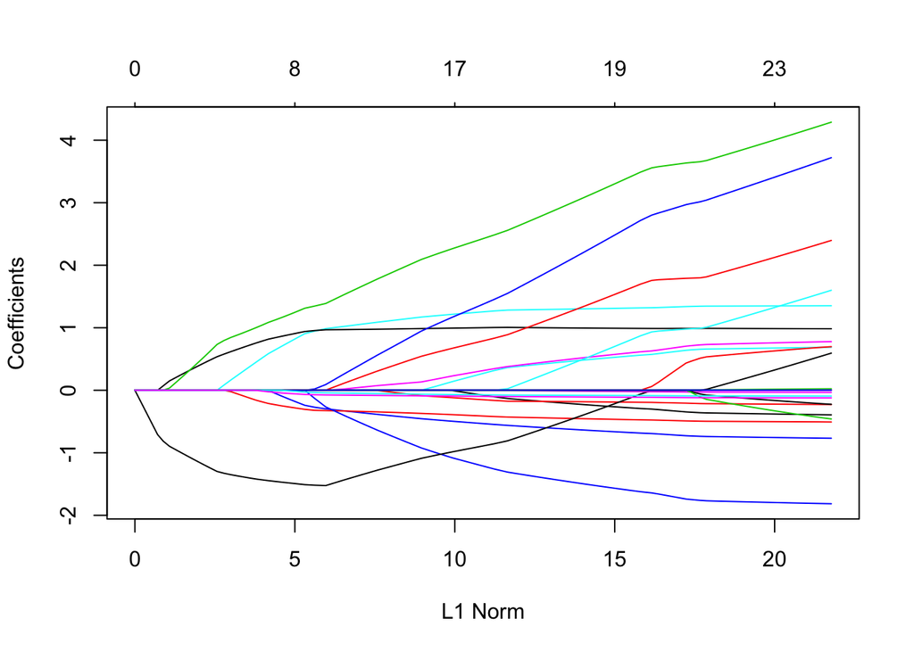

```r
#Plot the lasso
plot(elem.glm)
```

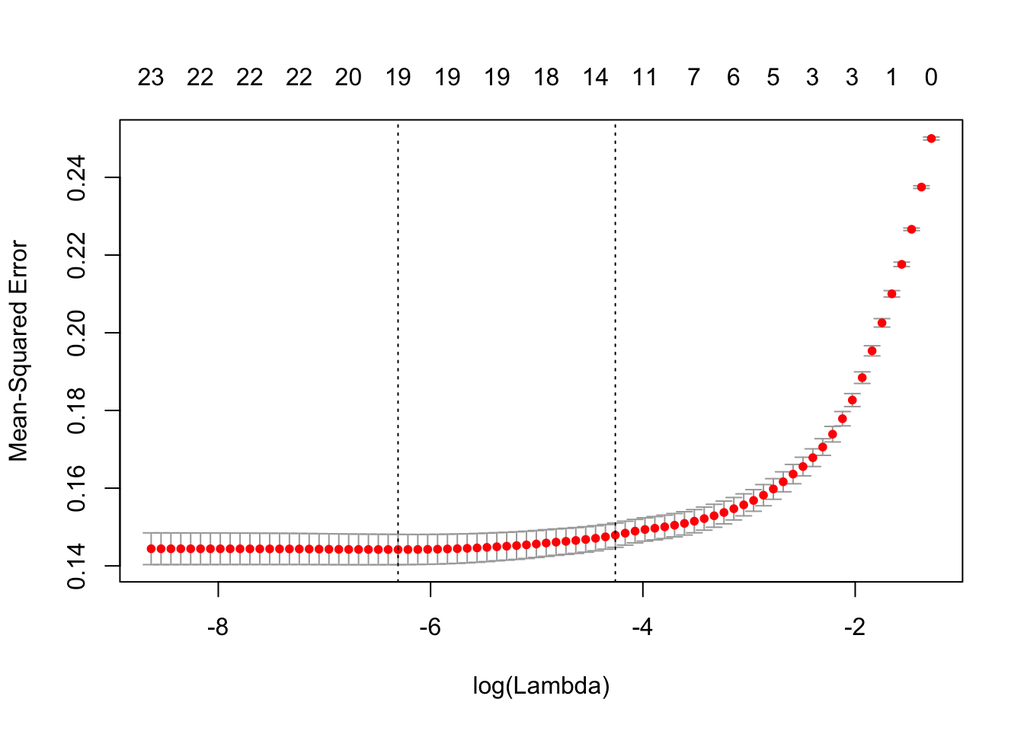

```r
#Fit the model on our test data
set.seed(1)
elem.out=cv.glmnet(elem.x[elem.train,],elem.y[elem.train],alpha=1)
plot(elem.out)
```

###### Determining coeffcients and significant predictors using lasso - Elementary

```r
#Figuring out the minimum lambda value and predicting CV error on test
elem.bestlam=elem.out$lambda.min
elem.1se=elem.out$lambda.1se
elem.lasso.pred=predict(elem.glm,s=elem.bestlam,newx=elem.x[elem.test,])
print("Minimum lambda for Elementary")
```

```
## [1] "Minimum lambda for Elementary"
```

```r
elem.bestlam
```

```
## [1] 0.001824545
```

```r
print("1SE lambda for Elementary")
```

```
## [1] "1SE lambda for Elementary"
```

```r
elem.1se
```

```
## [1] 0.01412679
```

```r
print("CV Error for Elementary")
```

```
## [1] "CV Error for Elementary"
```

```r
mean((elem.lasso.pred-elem.y.test)^2)
```

```
## [1] 3.006002
```

```r
#Determine which variables are non-zero at the 1se value of lambda
out=glmnet(elem.x,elem.y,alpha=1,family="binomial")
elem.lasso.coef=predict(out,type="coefficients",s=elem.1se)
elem.lasso.coef
```

```
## 25 x 1 sparse Matrix of class "dgCMatrix"
##                       1
## (Intercept) -0.24725217
## CHARTER1     .
## CHARTER2    -0.19000586
## VALID        .
## AA_SIGYes   -0.29449785
## AS_SIGYes    0.97507711
## HI_SIGYes    .
## WH_SIGYes    1.05803859
## SD_SIGYes   -0.40835440
## YR_RND1      .
## YR_RND2     -0.16039643
## ACS_CORE2    .
## ACS_CORE3    0.08841925
## AVG_ED2     -1.44232699
## AVG_ED3      0.27200197
## AVG_ED4      1.65019352
## AVG_ED5      0.38957982
## AVG_ED6      .
## NUMTEACH     .
## FULL_PCT     .
## EMER_PCT     .
## WVR_PCT      .
## YRS_TEACH    0.01131211
## YRONE_TCH   -0.01160518
## YRTWO_TCH   -0.05312920
```

```r
elem.lasso.coef[elem.lasso.coef!=0]
```

```
## <sparse>[ <logic> ] : .M.sub.i.logical() maybe inefficient
```

```
##  [1] -0.24725217 -0.19000586 -0.29449785  0.97507711  1.05803859
##  [6] -0.40835440 -0.16039643  0.08841925 -1.44232699  0.27200197
## [11]  1.65019352  0.38957982  0.01131211 -0.01160518 -0.05312920
```

##### Middle School

```r
#removing all rows where API is null
middle.reg2 = middle.reg

middle.x <- model.matrix(API~.,middle.reg2)[,-1]
middle.y <- as.matrix(data.frame(middle.reg$API))
middle.y <- as.numeric(middle.y)

# Split data into test and train
set.seed(1)
middle.train <- sample(1:nrow(middle.x), nrow(middle.x)/2)
middle.test <- (-middle.train)
middle.y.test <- middle.y[middle.test]

# If we want to specify the number of lambda values - not sure we actually need this
# Predefined grid of lambda values:
# grid=10^seq(10,-2, length =100)

#lasso
middle.glm <- glmnet(middle.x[middle.train,],middle.y[middle.train],family = "binomial",alpha=1)
middle.glm
```

```
##
## Call:  glmnet(x = middle.x[middle.train, ], y = middle.y[middle.train],      family = "binomial", alpha = 1)
##
##       Df    %Dev    Lambda
##  [1,]  0 0.00000 3.004e-01
##  [2,]  1 0.04428 2.737e-01
##  [3,]  1 0.08123 2.494e-01
##  [4,]  1 0.11220 2.272e-01
##  [5,]  2 0.14100 2.070e-01
##  [6,]  2 0.16840 1.887e-01
##  [7,]  2 0.19170 1.719e-01
##  [8,]  2 0.21160 1.566e-01
##  [9,]  2 0.22860 1.427e-01
## [10,]  2 0.24310 1.300e-01
## [11,]  3 0.25650 1.185e-01
```

[output cut: 87 more lines]

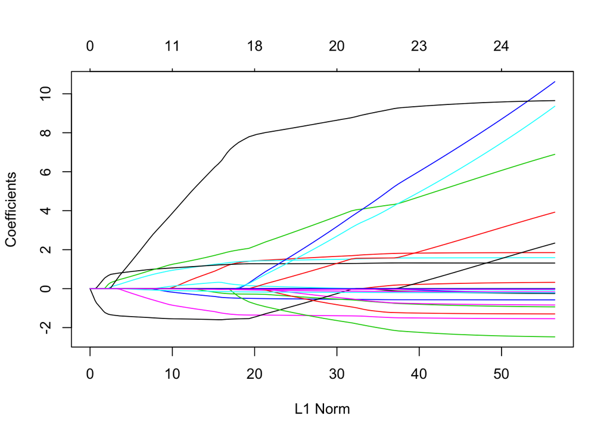

```r
#Plot the lasso
plot(middle.glm)
```

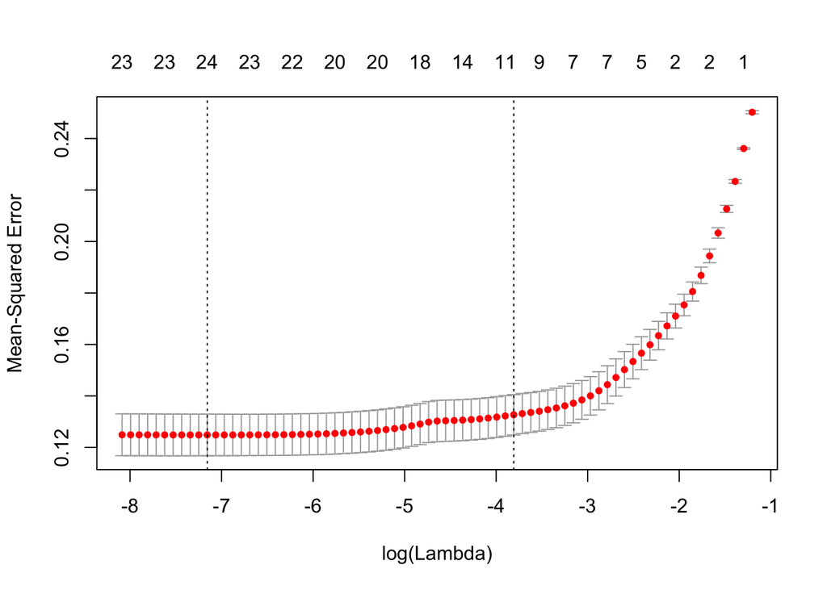

```r
set.seed(1)
middle.out=cv.glmnet(middle.x[middle.train,],middle.y[middle.train],alpha=1)
plot(middle.out)
```

###### Determining coeffcients and significant predictors using lasso - Middle

```r
#Figuring out the minimum lambda value and predicting CV error on test
middle.bestlam=middle.out$lambda.min
middle.1se=middle.out$lambda.1se
middle.lasso.pred=predict(middle.glm,s=middle.bestlam,newx=middle.x[middle.test,])
print("Minimum lambda for Middle")
```

```
## [1] "Minimum lambda for Middle"
```

```r
middle.bestlam
```

```
## [1] 0.0007795243
```

```r
print("1SE lambda for Middle")
```

```
## [1] "1SE lambda for Middle"
```

```r
middle.1se
```

```
## [1] 0.02220113
```

```r
print("CV Error for Middle")
```

```
## [1] "CV Error for Middle"
```

```r
mean((middle.lasso.pred-middle.y.test)^2)
```

```
## [1] 8.698486
```

```r
#Determine which variables are non-zero at the 1se value of lambda
out=glmnet(middle.x,middle.y,alpha=1,family="binomial")
middle.lasso.coef=predict(out,type="coefficients",s=middle.1se)
middle.lasso.coef
```

```
## 25 x 1 sparse Matrix of class "dgCMatrix"
##                       1
## (Intercept) -0.29396945
## CHARTER1     .
## CHARTER2     0.34703525
## VALID        .
## AA_SIGYes   -0.56520750
## AS_SIGYes    1.01514526
## HI_SIGYes   -0.32086206
## WH_SIGYes    1.09510768
## SD_SIGYes    .
## YR_RND1      .
## YR_RND2      .
## ACS_CORE2    0.19179161
## ACS_CORE3    .
## AVG_ED2     -1.71321792
## AVG_ED3      .
## AVG_ED4      1.24735563
## AVG_ED5      .
## AVG_ED6      .
## NUMTEACH     .
## FULL_PCT     0.46718157
## EMER_PCT     .
## WVR_PCT      .
## YRS_TEACH    .
## YRONE_TCH   -0.07687103
## YRTWO_TCH    .
```

```r
middle.lasso.coef[middle.lasso.coef!=0]
```

```
## <sparse>[ <logic> ] : .M.sub.i.logical() maybe inefficient
```

```
##  [1] -0.29396945  0.34703525 -0.56520750  1.01514526 -0.32086206
##  [6]  1.09510768  0.19179161 -1.71321792  1.24735563  0.46718157
## [11] -0.07687103
```

##### High School

```r
#removing all rows where API is null
high.reg2 = high.reg

high.x <- model.matrix(API~.,high.reg2)[,-1]
high.y <- as.matrix(data.frame(high.reg$API))
high.y <- as.numeric(high.y)

# Split data into test and train
set.seed(1)
high.train <- sample(1:nrow(high.x), nrow(high.x)/2)
high.test <- (-high.train)
high.y.test <- high.y[high.test]

# If we want to specify the number of lambda values - not sure we actually need this
# Predefined grid of lambda values:
# grid=10^seq(10,-2, length =100)

#lasso
high.glm <- glmnet(high.x[high.train,],high.y[high.train],family = "binomial",alpha=1)
high.glm
```

```
##
## Call:  glmnet(x = high.x[high.train, ], y = high.y[high.train], family = "binomial",      alpha = 1)
##
##       Df       %Dev    Lambda
##  [1,]  0 -1.610e-15 2.635e-01
##  [2,]  1  3.455e-02 2.401e-01
##  [3,]  1  6.345e-02 2.188e-01
##  [4,]  1  8.773e-02 1.993e-01
##  [5,]  1  1.082e-01 1.816e-01
##  [6,]  2  1.290e-01 1.655e-01
##  [7,]  2  1.502e-01 1.508e-01
##  [8,]  2  1.683e-01 1.374e-01
##  [9,]  4  1.882e-01 1.252e-01
## [10,]  4  2.087e-01 1.141e-01
## [11,]  4  2.265e-01 1.039e-01
```

[output cut: 77 more lines]

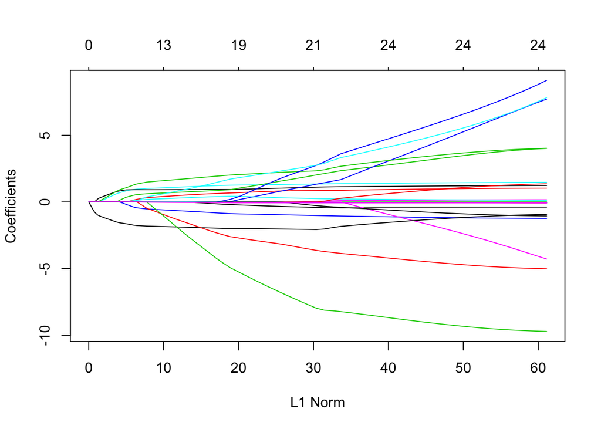

```r
#Plot the lasso
plot(high.glm)
```

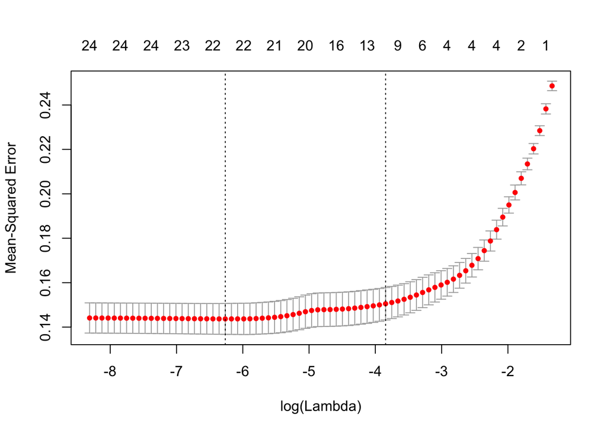

```r
set.seed(1)
high.out=cv.glmnet(high.x[high.train,],high.y[high.train],alpha=1)
plot(high.out)
```

######Determining coeffcients and significant predictors using lasso - High

```r
#Figuring out the minimum lambda value and predicting CV error on test
high.bestlam=high.out$lambda.min
high.1se=high.out$lambda.1se
high.lasso.pred=predict(high.glm,s=high.bestlam,newx=high.x[high.test,])
print("Minimum lambda for High")
```

```
## [1] "Minimum lambda for High"
```

```r
high.bestlam
```

```
## [1] 0.001902846
```

```r
print("1SE lambda for High")
```

```
## [1] "1SE lambda for High"
```

```r
high.1se
```

```
## [1] 0.02137513
```

```r
print("CV Error for High")
```

```
## [1] "CV Error for High"
```

```r
mean((high.lasso.pred-high.y.test)^2)
```

```
## [1] 5.361294
```

```r
#Determine which variables are non-zero at the 1se value of lambda
out=glmnet(high.x,high.y,alpha=1,family="binomial")
high.lasso.coef=predict(out,type="coefficients",s=high.1se)
high.lasso.coef
```

```
## 25 x 1 sparse Matrix of class "dgCMatrix"
##                      1
## (Intercept) -1.0300084
## CHARTER1     .
## CHARTER2     .
## VALID        .
## AA_SIGYes   -0.5732982
## AS_SIGYes    1.1388431
## HI_SIGYes    .
## WH_SIGYes    0.8485267
## SD_SIGYes    0.2559603
## YR_RND1      0.5110729
## YR_RND2      .
## ACS_CORE2    .
## ACS_CORE3    .
## AVG_ED2     -1.8152398
## AVG_ED3      .
## AVG_ED4      1.5636853
## AVG_ED5      .
## AVG_ED6      .
## NUMTEACH     .
## FULL_PCT     .
## EMER_PCT    -0.6632534
## WVR_PCT      .
## YRS_TEACH    .
## YRONE_TCH    .
## YRTWO_TCH    .
```

```r
high.lasso.coef[high.lasso.coef!=0]
```

```
## <sparse>[ <logic> ] : .M.sub.i.logical() maybe inefficient
```

```
## [1] -1.0300084 -0.5732982  1.1388431  0.8485267  0.2559603  0.5110729
## [7] -1.8152398  1.5636853 -0.6632534
```

#### Classification with Naive Bayes

##### Elementary School

```r
elem.nb = NaiveBayes(elementary.reg$API ~ ., data = elementary.reg, usekernal = TRUE)
elem.nb.pred = predict(elem.nb,elementary.reg)
table(elem.nb.pred$class, elementary.reg$API)
```

```
##
##        0    1
##   0 1975  497
##   1  663 2076
```

```r
cat("\n")
```

```r
print("Misclassification Rate")
```

```
## [1] "Misclassification Rate"
```

```r
mean(elem.nb.pred$class != elementary.reg$API)
```

```
## [1] 0.222606
```

##### Middle School

```r
middle.nb = NaiveBayes(middle.reg$API ~ ., data = middle.reg, usekernal = TRUE)
middle.nb.pred = predict(middle.nb,middle.reg)
table(middle.nb.pred$class, middle.reg$API)
```

```
##
##       0   1
##   0 332  68
##   1 264 519
```

```r
cat("\n")
```

```r
print("Misclassification Rate")
```

```
## [1] "Misclassification Rate"
```

```r
mean(middle.nb.pred$class != middle.reg$API)
```

```
## [1] 0.2806424
```

##### High School

```r
high.nb = NaiveBayes(high.reg$API ~ ., data = high.reg, usekernal = TRUE)
high.nb.pred = predict(high.nb,high.reg)
table(high.nb.pred$class, high.reg$API)
```

```
##
##       0   1
##   0 396  89
##   1 282 478
```

```r
cat("\n")
```

```r
print("Misclassification Rate")
```

```
## [1] "Misclassification Rate"
```

```r
mean(high.nb.pred$class != high.reg$API)
```

```
## [1] 0.297992
```

#### Decisions Trees

```r
treeFun <- function(dataset){
  tree <- rpart(API~.,data = dataset, method = "class")
  tree.party <- as.party(tree)
  plot(tree.party, gp = gpar(fontsize = 7))
  print(tree.party)
  return(tree)
}

treePruned <- function(tree){
   min.cv.idx <- which.min(tree$cptable[,"xerror"])
  # min CV error + 1se (this is the height of the horizontal bar)
  min.cv.err.1se <- tree$cptable[min.cv.idx,"xerror"] +
                   tree$cptable[min.cv.idx,"xstd"]
  # Which cp values produce models whose error is below min CV + 1se?
  cp.vals <- tree$cptable[which(tree$cptable[,"xerror"] < min.cv.err.1se),"CP"]

  # 1-SE rule value of cp
  cp.1se <- max(cp.vals)

  #Prune tree
  pruned.tree <- prune(tree, cp = cp.1se)
  tree.party<-as.party(pruned.tree)
  plot(tree.party, gp = gpar(fontsize = 7))
  print(tree.party)
  return(pruned.tree)
}
```

##### Elementary School Tree

```r
#To prune or not to prune?
elementary.tree <- treeFun(elementary.train)
```

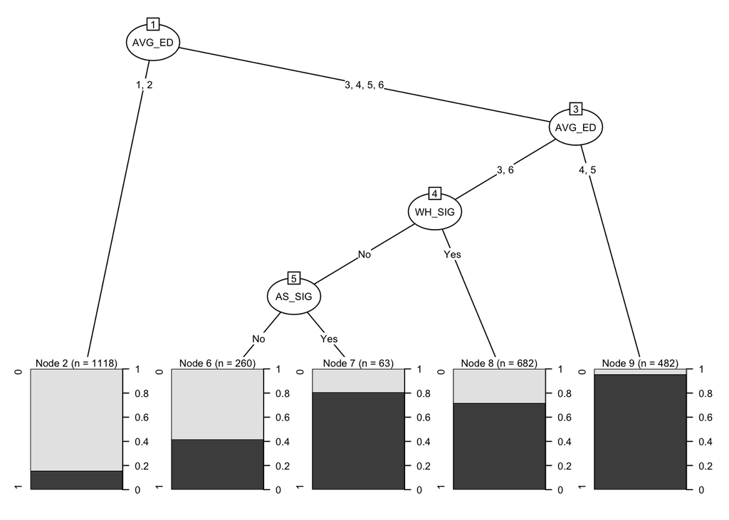

```
##
## Model formula:
## API ~ CHARTER + VALID + AA_SIG + AS_SIG + HI_SIG + WH_SIG + SD_SIG +
##     YR_RND + ACS_CORE + AVG_ED + NUMTEACH + FULL_PCT + EMER_PCT +
##     WVR_PCT + YRS_TEACH + YRONE_TCH + YRTWO_TCH
##
## Fitted party:
## [1] root
## |   [2] AVG_ED in 1, 2: 0 (n = 1118, err = 15.7%)
## |   [3] AVG_ED in 3, 4, 5, 6
## |   |   [4] AVG_ED in 3, 6
## |   |   |   [5] WH_SIG in No
## |   |   |   |   [6] AS_SIG in No: 0 (n = 260, err = 41.9%)
## |   |   |   |   [7] AS_SIG in Yes: 1 (n = 63, err = 19.0%)
## |   |   |   [8] WH_SIG in Yes: 1 (n = 682, err = 28.3%)
## |   |   [9] AVG_ED in 4, 5: 1 (n = 482, err = 4.6%)
##
## Number of inner nodes:    4
## Number of terminal nodes: 5
```

```r
elementary.tree <- treePruned(elementary.tree)
```

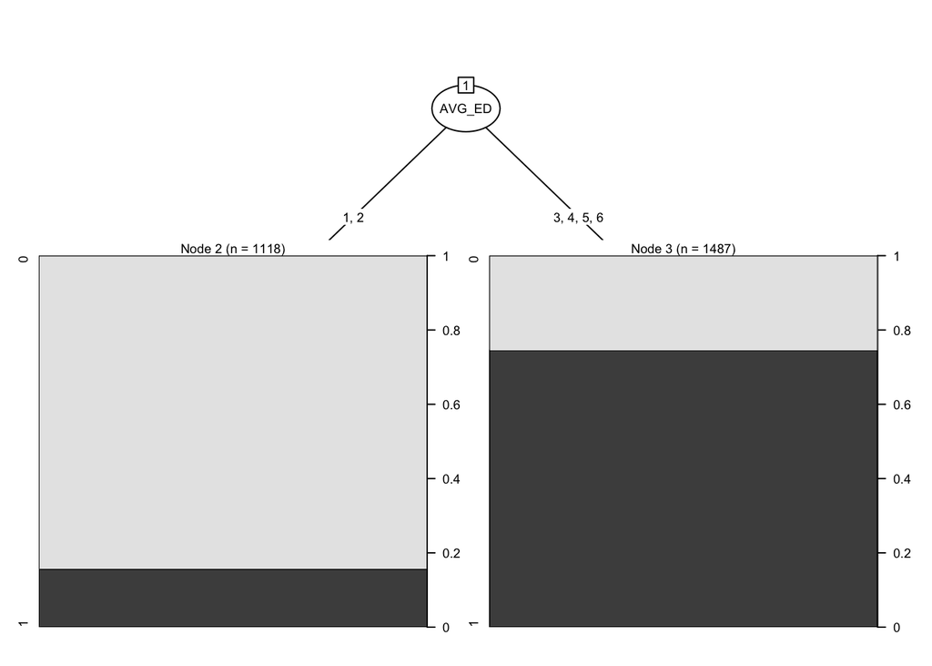

```
##
## Model formula:
## API ~ CHARTER + VALID + AA_SIG + AS_SIG + HI_SIG + WH_SIG + SD_SIG +
##     YR_RND + ACS_CORE + AVG_ED + NUMTEACH + FULL_PCT + EMER_PCT +
##     WVR_PCT + YRS_TEACH + YRONE_TCH + YRTWO_TCH
##
## Fitted party:
## [1] root
## |   [2] AVG_ED in 1, 2: 0 (n = 1118, err = 15.7%)
## |   [3] AVG_ED in 3, 4, 5, 6: 1 (n = 1487, err = 25.4%)
##
## Number of inner nodes:    1
## Number of terminal nodes: 2
```

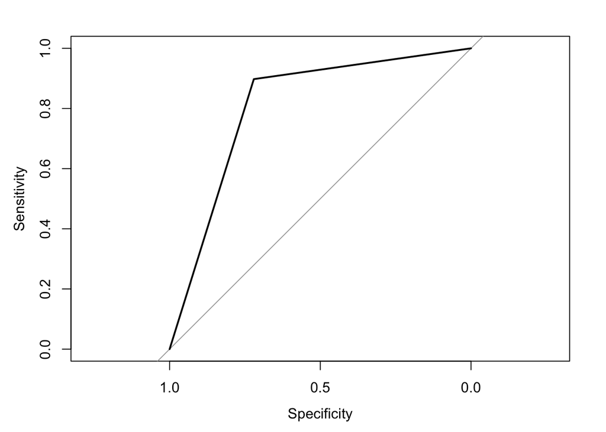

```r
elem.test.prob <- predict(elementary.tree, newdata = elementary.test, type = "prob")[,"1"]
roc.elem <- roc(elementary.test$API, elem.test.prob)
plot(roc.elem)
```

```r
classMetrics(elem.test.prob, elementary.test$API, cutoff = 0.5)
```

```
## $conf.mat
##          observed
## predicted    0    1
##         0  949  132
##         1  368 1157
##
## $perf
##                 value
## accuracy    0.8081351
## sensitivity 0.8975950
## specificity 0.7205771
## ppv         0.7586885
## npv         0.8778908
## precision   0.7586885
## recall      0.8975950
```

##### Middle School Tree

```r
middle.tree <- treeFun(middleschool.train)
```

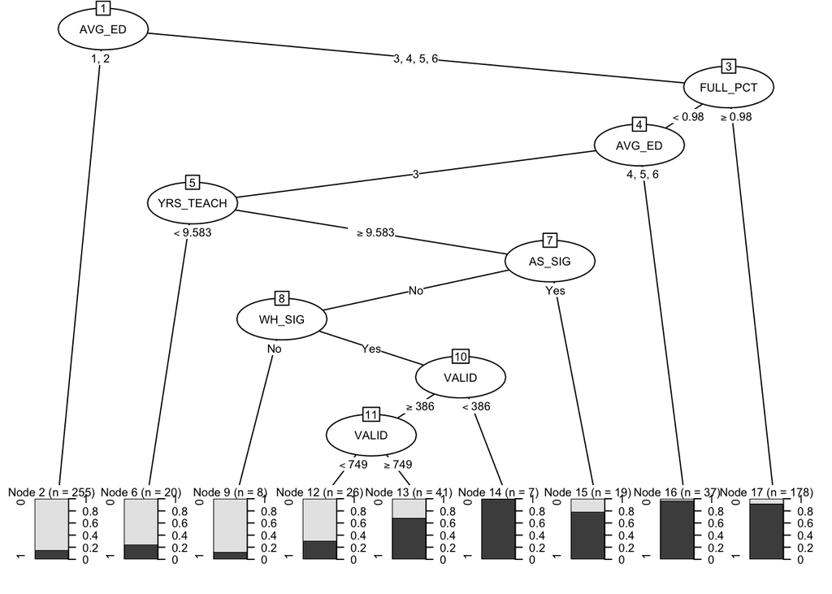

```
##
## Model formula:
## API ~ CHARTER + VALID + AA_SIG + AS_SIG + HI_SIG + WH_SIG + SD_SIG +
##     YR_RND + ACS_CORE + AVG_ED + NUMTEACH + FULL_PCT + EMER_PCT +
##     WVR_PCT + YRS_TEACH + YRONE_TCH + YRTWO_TCH
##
## Fitted party:
## [1] root
## |   [2] AVG_ED in 1, 2: 0 (n = 255, err = 15.7%)
## |   [3] AVG_ED in 3, 4, 5, 6
## |   |   [4] FULL_PCT < 0.98015
## |   |   |   [5] AVG_ED in 3
## |   |   |   |   [6] YRS_TEACH < 9.58314: 0 (n = 20, err = 25.0%)
## |   |   |   |   [7] YRS_TEACH >= 9.58314
## |   |   |   |   |   [8] AS_SIG in No
## |   |   |   |   |   |   [9] WH_SIG in No: 0 (n = 8, err = 12.5%)
## |   |   |   |   |   |   [10] WH_SIG in Yes
## |   |   |   |   |   |   |   [11] VALID >= 386
## |   |   |   |   |   |   |   |   [12] VALID < 749: 0 (n = 26, err = 30.8%)
## |   |   |   |   |   |   |   |   [13] VALID >= 749: 1 (n = 41, err = 31.7%)
## |   |   |   |   |   |   |   [14] VALID < 386: 1 (n = 7, err = 0.0%)
## |   |   |   |   |   [15] AS_SIG in Yes: 1 (n = 19, err = 21.1%)
## |   |   |   [16] AVG_ED in 4, 5, 6: 1 (n = 37, err = 2.7%)
## |   |   [17] FULL_PCT >= 0.98015: 1 (n = 178, err = 8.4%)
##
## Number of inner nodes:    8
## Number of terminal nodes: 9
```

```r
middle.tree <- treePruned(middle.tree)
```

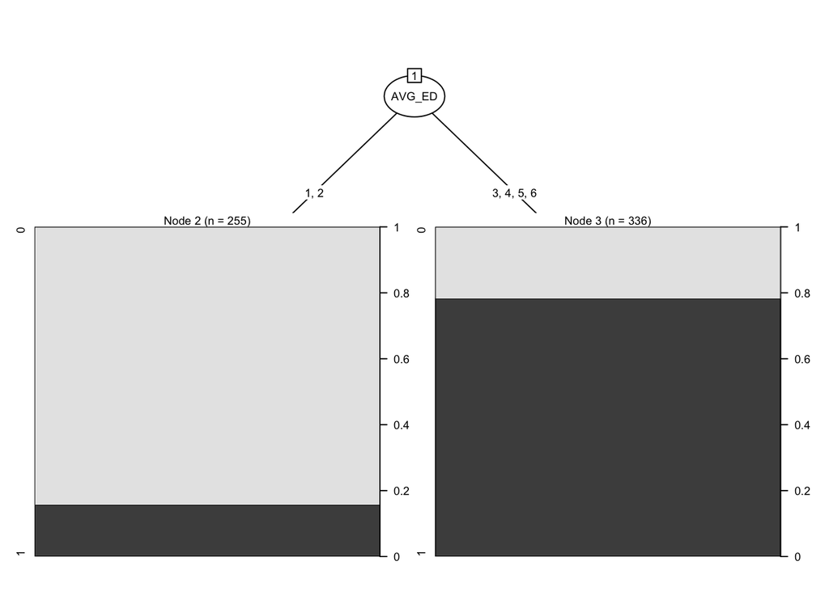

```
##
## Model formula:
## API ~ CHARTER + VALID + AA_SIG + AS_SIG + HI_SIG + WH_SIG + SD_SIG +
##     YR_RND + ACS_CORE + AVG_ED + NUMTEACH + FULL_PCT + EMER_PCT +
##     WVR_PCT + YRS_TEACH + YRONE_TCH + YRTWO_TCH
##
## Fitted party:
## [1] root
## |   [2] AVG_ED in 1, 2: 0 (n = 255, err = 15.7%)
## |   [3] AVG_ED in 3, 4, 5, 6: 1 (n = 336, err = 21.7%)
##
## Number of inner nodes:    1
## Number of terminal nodes: 2
```

###### Middle School Confusion Matrix

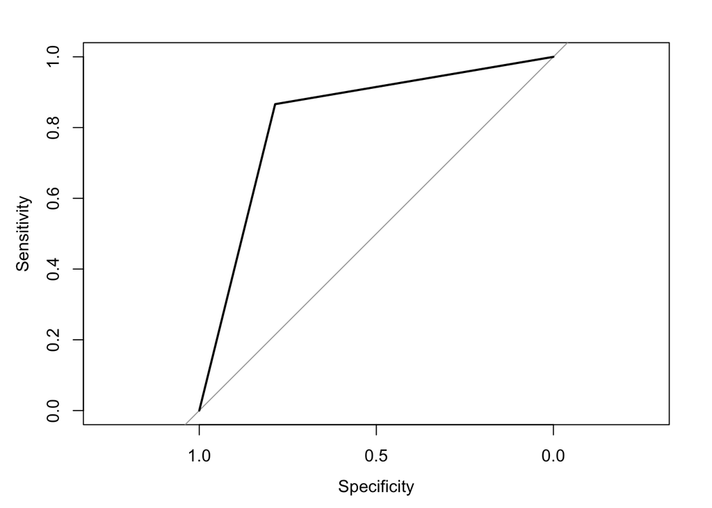

```r
middle.test.prob <- predict(middle.tree, newdata = middleschool.test, type = "prob")[,"1"]
roc.middle <- roc(middleschool.test$API, middle.test.prob)
plot(roc.middle)
```

```r
classMetrics(middle.test.prob, middleschool.test$API, cutoff = 0.4)
```

```
## $conf.mat
##          observed
## predicted   0   1
##         0 242  38
##         1  66 246
##
## $perf
##                 value
## accuracy    0.8243243
## sensitivity 0.8661972
## specificity 0.7857143
## ppv         0.7884615
## npv         0.8642857
## precision   0.7884615
## recall      0.8661972
```

##### High School Tree

```r
high.tree <- treeFun(highschool.train)
```

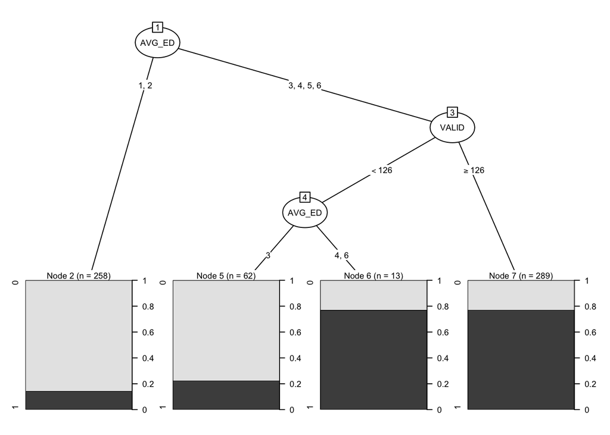

```
##
## Model formula:
## API ~ CHARTER + VALID + AA_SIG + AS_SIG + HI_SIG + WH_SIG + SD_SIG +
##     YR_RND + ACS_CORE + AVG_ED + NUMTEACH + FULL_PCT + EMER_PCT +
##     WVR_PCT + YRS_TEACH + YRONE_TCH + YRTWO_TCH
##
## Fitted party:
## [1] root
## |   [2] AVG_ED in 1, 2: 0 (n = 258, err = 14.3%)
## |   [3] AVG_ED in 3, 4, 5, 6
## |   |   [4] VALID < 126
## |   |   |   [5] AVG_ED in 3: 0 (n = 62, err = 22.6%)
## |   |   |   [6] AVG_ED in 4, 6: 1 (n = 13, err = 23.1%)
## |   |   [7] VALID >= 126: 1 (n = 289, err = 22.8%)
##
## Number of inner nodes:    3
## Number of terminal nodes: 4
```

```r
high.tree <- treePruned(high.tree)
```

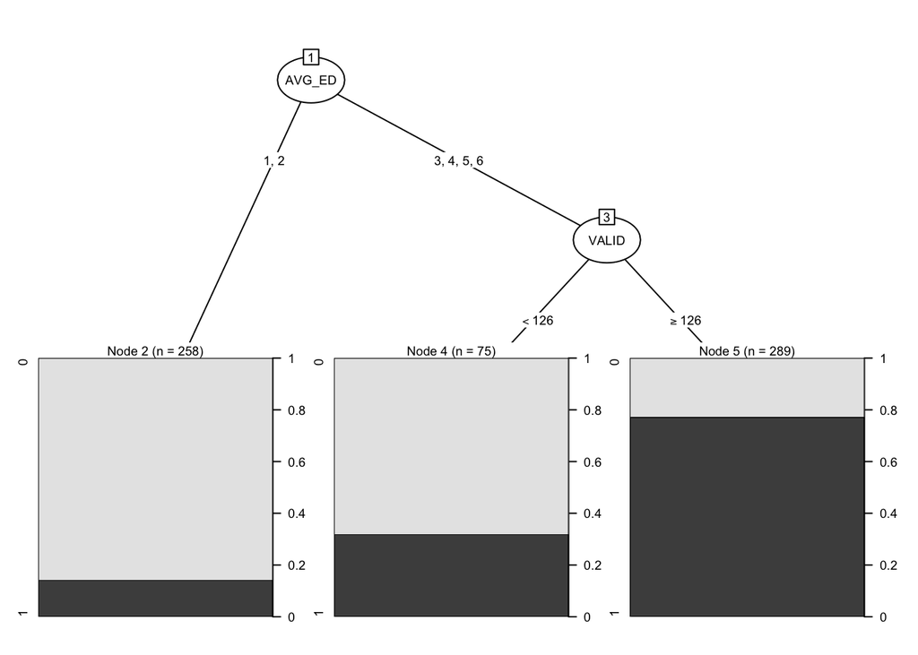

```
##
## Model formula:
## API ~ CHARTER + VALID + AA_SIG + AS_SIG + HI_SIG + WH_SIG + SD_SIG +
##     YR_RND + ACS_CORE + AVG_ED + NUMTEACH + FULL_PCT + EMER_PCT +
##     WVR_PCT + YRS_TEACH + YRONE_TCH + YRTWO_TCH
##
## Fitted party:
## [1] root
## |   [2] AVG_ED in 1, 2: 0 (n = 258, err = 14.3%)
## |   [3] AVG_ED in 3, 4, 5, 6
## |   |   [4] VALID < 126: 0 (n = 75, err = 32.0%)
## |   |   [5] VALID >= 126: 1 (n = 289, err = 22.8%)
##
## Number of inner nodes:    2
## Number of terminal nodes: 3
```

###### High School Confusion Matrix

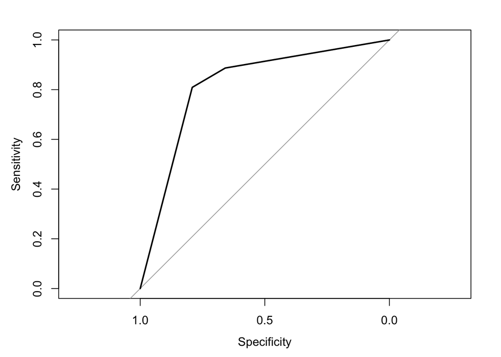

```r
high.test.prob <- predict(high.tree, newdata = highschool.test, type = "prob")[,"1"]
roc.high <- roc(highschool.test$API, high.test.prob)
plot(roc.high)
```

```r
classMetrics(high.test.prob, highschool.test$API, cutoff = 0.4)
```

```
## $conf.mat
##          observed
## predicted   0   1
##         0 269  54
##         1  71 229
##
## $perf
##                 value
## accuracy    0.7993579
## sensitivity 0.8091873
## specificity 0.7911765
## ppv         0.7633333
## npv         0.8328173
## precision   0.7633333
## recall      0.8091873
```

#### Random Forest

##### Elementary School

```r
elementary.train=elementary.train %>% mutate_if(is.character, as.factor)
elementary.test=elementary.test %>% mutate_if(is.character, as.factor)
elementary.rf <- randomForest(API~., data = elementary.train, mtry=4, importance=TRUE)
print(elementary.rf)
```

```
##
## Call:
##  randomForest(formula = API ~ ., data = elementary.train, mtry = 4,      importance = TRUE)
##                Type of random forest: classification
##                      Number of trees: 500
## No. of variables tried at each split: 4
##
##         OOB estimate of  error rate: 21.04%
## Confusion matrix:
##      0    1 class.error
## 0 1042  279   0.2112036
## 1  269 1015   0.2095016
```

```r
importance(elementary.rf)
```

```
##                   0          1 MeanDecreaseAccuracy MeanDecreaseGini
## CHARTER    7.991807  4.0991533            9.3397667        13.718519
## VALID     14.147912 16.6258904           27.0514827       146.826328
## AA_SIG     7.930864  8.6887418           11.6003809        14.896561
## AS_SIG    16.164053 19.1068846           25.6878550        30.715570
## HI_SIG    15.364283 -0.3087196           15.9845702        30.735368
## WH_SIG    15.163433 35.9630702           38.7642235       123.714117
## SD_SIG    15.917783 13.1609906           22.9771845        51.189281
## YR_RND    -3.633635  4.3644668            0.4359957         7.835942
## ACS_CORE   6.131628  1.6693072            5.4457776        13.858271
## AVG_ED    62.614046 62.6278115           86.4108563       309.018926
## NUMTEACH  16.275746 19.3603132           29.2288460       111.723667
## FULL_PCT   3.667895  6.4818659            7.6488667        46.449153
## EMER_PCT   1.334585  1.1577947            1.8374239        23.992674
## WVR_PCT   -2.408849  2.1707955           -0.2734168         6.487352
## YRS_TEACH  6.043943  9.6726710           11.7085442       145.559499
## YRONE_TCH  4.922081  7.6599729            8.9596651        42.343552
## YRTWO_TCH  8.236251 12.7560677           15.3876948        53.132782
```

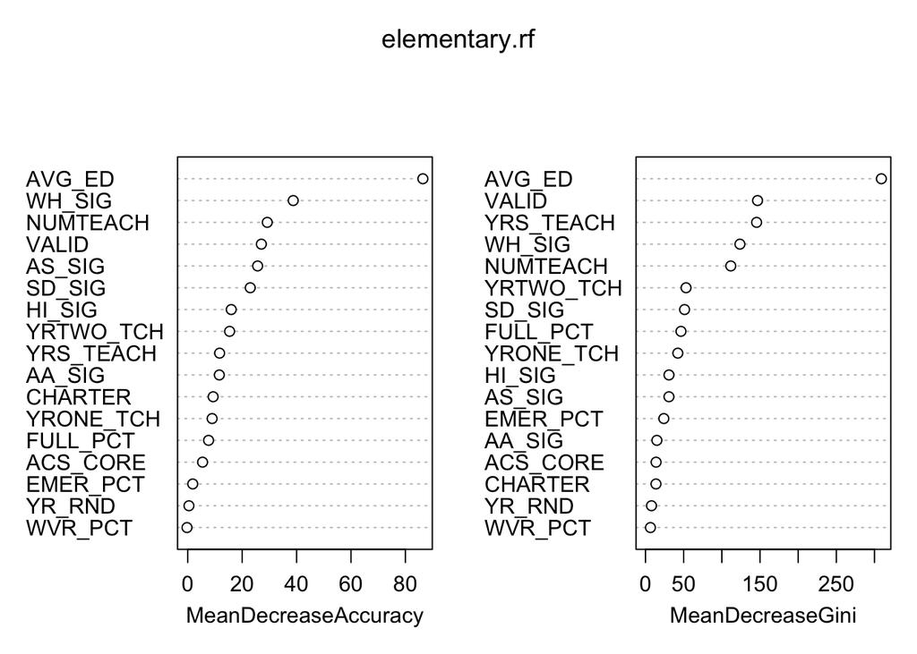

```r
varImpPlot(elementary.rf)
```

```r
predict.elem <- predict(elementary.rf, newdata = elementary.test, type = "prob")[,"1"]
classMetrics(predict.elem, elementary.test$API, cutoff = 0.3)
```

```
## $conf.mat
##          observed
## predicted    0    1
##         0  890  111
##         1  427 1178
##
## $perf
##                 value
## accuracy    0.7935533
## sensitivity 0.9138867
## specificity 0.6757783
## ppv         0.7339564
## npv         0.8891109
## precision   0.7339564
## recall      0.9138867
```

##### Middle School

```r
#Test?
middleschool.train=middleschool.train %>% mutate_if(is.character, as.factor)
middleschool.test=middleschool.test %>% mutate_if(is.character, as.factor)
middle.rf <- randomForest(API~., data = middleschool.train, mtry=4, importance=TRUE)
print(middle.rf)
```

```
##
## Call:
##  randomForest(formula = API ~ ., data = middleschool.train, mtry = 4,      importance = TRUE)
##                Type of random forest: classification
##                      Number of trees: 500
## No. of variables tried at each split: 4
##
##         OOB estimate of  error rate: 17.43%
## Confusion matrix:
##     0   1 class.error
## 0 242  46   0.1597222
## 1  57 246   0.1881188
```

```r
importance(middle.rf)
```

```
##                    0          1 MeanDecreaseAccuracy MeanDecreaseGini
## CHARTER    1.0212520  0.6854727           1.36676453        0.9805211
## VALID      7.4028887 10.8132248          13.75634849       26.4151136
## AA_SIG    -0.9161943  6.5519633           5.10110027        3.5455150
## AS_SIG    11.4409239  7.1171333          12.19114896        9.8321967
## HI_SIG    15.8093696  3.4078838          15.81447465        5.8268509
## WH_SIG    15.0846420 25.1685630          27.49269369       34.0832612
## SD_SIG    10.3231295 -0.3279868           9.22732355        3.6466192
## YR_RND     0.4581664 -0.3750233           0.06562918        0.7982804
## ACS_CORE   1.7249795  2.6656940           3.00520761        5.8760828
## AVG_ED    28.6009571 48.2829978          49.44785898       66.0751811
## NUMTEACH   6.0609958  7.0507460           9.71642638       22.9843098
## FULL_PCT  12.9755551 13.0993562          17.59895465       33.8223705
## EMER_PCT   2.5327757  0.9182817           2.47714354       10.0016983
## WVR_PCT   -5.5672563  1.7191498          -2.83946225        3.8884338
## YRS_TEACH  1.1550147  4.9054905           4.35265941       28.2792001
## YRONE_TCH 10.3233558  5.4087573          11.21491302       14.5696015
## YRTWO_TCH  6.5359075  7.7942726          10.78959342       16.5626413
```

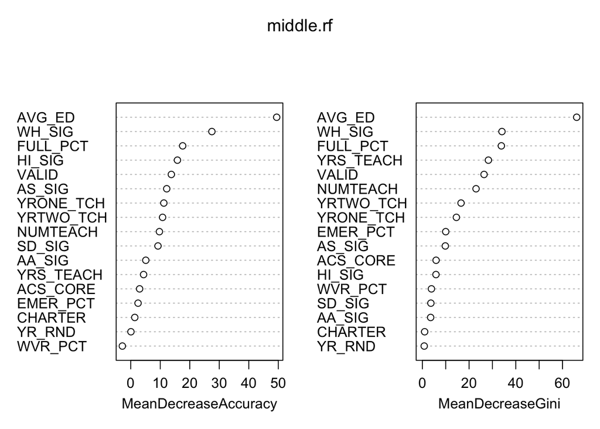

```r
varImpPlot(middle.rf)
```

```r
predict.middle <- predict(middle.rf, newdata = middleschool.test, type = "prob")[,"1"]
classMetrics(predict.middle, middleschool.test$API, cutoff = 0.3)
```

```
## $conf.mat
##          observed
## predicted   0   1
##         0 210  27
##         1  98 257
##
## $perf
##                 value
## accuracy    0.7888514
## sensitivity 0.9049296
## specificity 0.6818182
## ppv         0.7239437
## npv         0.8860759
## precision   0.7239437
## recall      0.9049296
```

##### High School

```r
highschool.train=highschool.train %>% mutate_if(is.character, as.factor)
highschool.test=highschool.train %>% mutate_if(is.character, as.factor)
high.rf <- randomForest(API~., data = highschool.train, mtry=4, importance=TRUE)
print(high.rf)
```

```
##
## Call:
##  randomForest(formula = API ~ ., data = highschool.train, mtry = 4,      importance = TRUE)
##                Type of random forest: classification
##                      Number of trees: 500
## No. of variables tried at each split: 4
##
##         OOB estimate of  error rate: 18.49%
## Confusion matrix:
##     0   1 class.error
## 0 284  54   0.1597633
## 1  61 223   0.2147887
```

```r
importance(high.rf)
```

```
##                    0          1 MeanDecreaseAccuracy MeanDecreaseGini
## CHARTER    1.8780145  9.7605518             9.084783         6.075181
## VALID     19.8324103 11.1715155            24.711522        37.397770
## AA_SIG     0.4788067  7.0615881             5.507414         3.397245
## AS_SIG    12.2916075 16.3570473            20.399955        12.982696
## HI_SIG     9.2071927 -2.8121175             8.040754         2.746231
## WH_SIG    14.9993278 16.8211997            22.627049        24.394397
## SD_SIG     5.1329386  1.3166776             5.731454         2.264372
## YR_RND     0.7774766  4.9515293             4.581920         2.280823
## ACS_CORE   2.1917889  0.2283774             1.695916         4.686732
## AVG_ED    38.6737091 57.3397730            60.685174        68.168903
## NUMTEACH   7.7707620  7.6449724            13.538089        29.913401
## FULL_PCT   9.0656812  9.3758728            13.732750        26.257155
## EMER_PCT   5.6808456  0.2268589             4.583186        14.207704
## WVR_PCT   -0.2575741 -2.2909817            -1.923004         3.937841
## YRS_TEACH  2.5162513  3.7658904             4.634707        30.280213
## YRONE_TCH  3.4178376 -1.3933577             1.959868        13.876965
## YRTWO_TCH  7.9025329  1.4390161             7.741519        17.070492
```

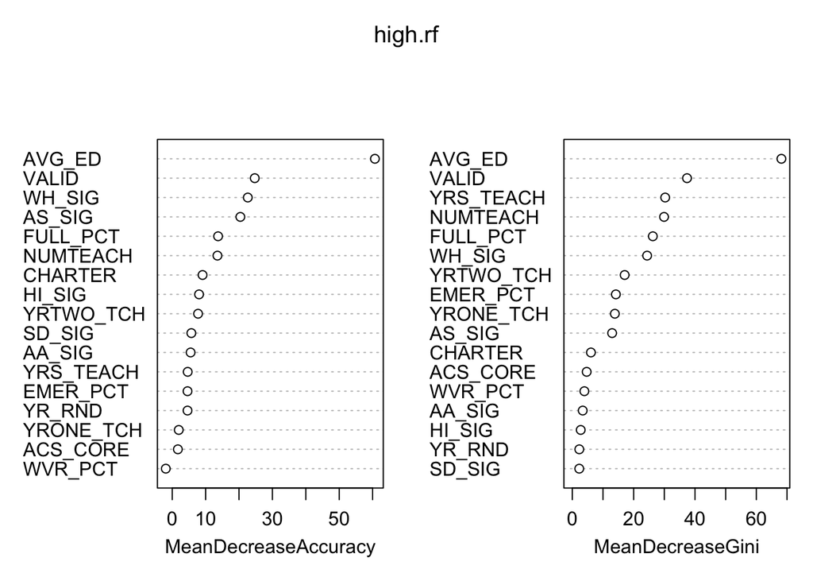

```r
varImpPlot(high.rf)
```

```r
predict.high <- predict(high.rf, newdata = highschool.test, type = "prob")[,"1"]
classMetrics(predict.high, highschool.test$API, cutoff = 0.3)
```

```
## $conf.mat
##          observed
## predicted   0   1
##         0 322   0
##         1  16 284
##
## $perf
##                 value
## accuracy    0.9742765
## sensitivity 1.0000000
## specificity 0.9526627
## ppv         0.9466667
## npv         1.0000000
## precision   0.9466667
## recall      1.0000000
```

###### Prevalence

```r
cat("Number of 1s for elementary school \n")
```

```
## Number of 1s for elementary school
```

```r
length(which(elementary.reg$API == "1")) / nrow(elementary.reg)
```

```
## [1] 0.4937632
```

```r
cat("Number of 1s for middle school \n")
```

```
## Number of 1s for middle school
```

```r
length(which(middle.reg$API == "1")) / nrow(middle.reg)
```

```
## [1] 0.4961961
```

```r
cat("Number of 1s for high school \n")
```

```
## Number of 1s for high school
```

```r
length(which(high.reg$API == "1")) / nrow(high.reg)
```

```
## [1] 0.4554217
```

# Section 2: Key Findings, Main Takeaways

## Question 1 - What are the Key Determinents of School Success?

# Question 1

Statistically Significant Variables Logistic Regression Elementary: Charter 2 Valid AA_SIGYes AS_SIG_Yes WH_SIGYes SD_SIGYes YR_RND2 ACS_CORE3 AVG_ED3 AVG_ED4 AVG_ED5 AVG_ED6 NUMTEACH YRTWO_TCH

Middle: Charter 2 Valid AA_SIGYes AS_SIGYes WH_SIGYes SD_SIGYes YR_RND2 ACS_CORE3 AVG_ED3 AVG_ED4 AVG_ED5 AVG_ED6 NUMTEACH YRTWO_TCH

High: VALID  
AA_SIGYes  
AS_SIGYes  
WH_SIGYes  
SD_SIGYes  
AVG_ED3  
AVG_ED4  
AVG_ED6  
NUMTEACH

Forward Stepwise Selection: Elementary: Charter2 AA_SIGYes AS_SIGYes WH_SIGYes SD_SIGYes YR_RND2 ACS_CORE2 ACS_CORE3 AVG_ED2 AVG_ED3 AVG_ED4 AVG_ED5 AVG_ED6 YRTWO_TCH

Middle: Charter2 Valid AA_SIGYes AS_SIGYes HI_SIGYes WH_SIGYes ACS_CORE2 AVG_ED2 AVG_ED3 AVG_ED4 AVG_ED5 AVG_ED6 NUMTEACH FULL_PCT YRONE_TCH

High: VALID AA_SIGYes AS_SIGYes WH_SIGYes SD_SIGYes YR_RND1 AVG_ED2 AVG_ED3 AVG_ED4 AVG_ED5 AVG_ED6 NUMTEACH EMER_PCT YRONE_TCH

Lasso Elementary: Charter2 AA_SIGYes AS_SIGYes WH_SIGYes SD_SIGYes YR_RND2 ACS_CORE3 AVG_ED2 AVG_ED3 AVG_ED4 AVG_ED5 YRS_TEACH YRONE_TCH TRTWO_TCH

Middle: Charter2 AA_SIGYes AS_SIGYes HI_SIGYes WH_SIGYes ACS_Core2 AVG_ED2 AVG_ED4 FULL_PCT YRONE_TCH

High: AA_SIGYes AS_SIGYes WH_SIGYes SD_SIGYes YR_RND1 AVG_ED2 AVG_ED4 EMER_PCT

Pruned Tree: Elementary: AVG_ED

Middle AVG_ED

High AVG_ED Valid

Random Forest Elementary: (In order of importance) AVG_ED WH_SIG NUMTEACH VALID AS_SIG SD_SIG

Middle: (In order of importance) AVG_ED WH_SIG FULL_PCT HI_SIG VALID AS_SIG

High: (In order of importance) AVG_ED VALID WH_SIG AS_SIG FULL_PCT NUMTEACH

## Question 2 - Do key determinants and their importance vary between school levels?

**The key determinants and their importance do vary slightly between school levels. Under our Random Forest model, most variables stay the same between school levels. AVG_ED, WH_SIG, AS_SIG, and VALID show up across all levels. NUMTEACH is significant in both high and elementary. FULL_PCT shows up in both middle and high school. When we look at our logistic regression, forward stepwise selection, and lasso models, we can see that the teacher variables (YRS_TEACH, NUMTEACH, YRTWO_TEACH, YRONE_TEACH) show up significantly more often during elementary and middle school. This seems to imply that the quality and experience of teachers are more important in early education than later education. Additionally, Charter2 (Which indicates funded-Charter schools) are more of a determining factor for elementary and middle schools. This variable is not important for high schools.**

## Data Limitations

**There are some limitations with this data. First of all, We didn’t like how the scores were ranked “Low” and “High”. This means that there is a cutoff and we are not considering the people right at the end or beginning of the cutoff. For example: If the cutoff score is 50, we are categorizing people who made 49 differently even though they might be the same as those who made 50. Also, we are testing different tests among different school levels, so it’s hard to compare across them. In addition to the issues states above, there were too many NULL values. Some of the findings we got were useless because it involved a categorical variable that represented ‘NA’**